# One-Class Classification

*Regular classification* or *cost-sensitive classification* are supervised learning methods, class labels are given for each observation and are used to train the model. Classification methods, therefore, are provided with the information of which observations belongs to which class and thus can *learn* class patterns and apply those onto new data. To learn the patterns a sufficient number of observations in each class is required and (nearly) balanced class sizes.

But what if there are no labels in the data?

And what if the class sizes a *very very* unbalanced?

And what if there is one class with a *very very* small number of observations?

If you have all of those cases in your data, you probably need to apply *Anomaly Detection methods*.

An *anomaly* is “something that deviates from what is standard, normal, or expected” [Oxford English Dictionary]. In the sense of data, anomalies are observations, which deviates from the majority of the data [Amer et al., 2013, p.1]. In different application domains anomalies are also referred to as *outliers*, *discordant observations*, *exceptions*, *aberrations*, *surprises*, *peculiarities*, *contaminants* [Chandola et al., 2009, p.1], *novelties*, *noise* or *deviations* [Dau et al., 2014, p.2].

There are two ways of handling anomalies, either delete them for example to yield statistically significant increase in accuracy [Smith and Martinez, 2011, p.1] or translate them into significant actionable information [Chandola et al., 2009, p.1] [Hodge and Austin, 2004, p.1] [Dau et al., 2014, p.1]. An example for the former case would be anomalies caused by measurement errors, which one want to remove from the data. For the latter case, a typical example is anomalous traffic pattern in a computer network, which could be interpreted as a hacker attack [Kumar., 2005] and which one obviously want to prevent. Methods to find anomalies and delete, modify or ignore them are often referred to as noise removal and noise accommodation [Hodge and Austin, 2004, p.4]. Whereas methods to find anomalies to extract relevant information are referred to as *anomaly detection*.

A special case of *Anomaly Detection* is the *one-class classification*. As the name *one-class learning* already says, the problem is that most of the time we only have the observation of one class, namely the *normal* class. It is easy to collect the normal situation, for example, production machines are probably nearly always run as it should, aircraft machinery works like it should and so on. It is hard to simulate the situation which is not normal, and even if we would be able to simulate this situation, we wouldn’t know if we cover all possible situations of anomalies. Therefore, a binary classification problem is most likely not sufficient to detect “unseen” anomalies as anomalies.

## One-class classification approach

The *one-class classification* approach is a *semi-supervised* learning approach. One requirement to apply *one-class classification* methods is to have training data, which only consists of *normal* observations (therefore *semi-supervised*). The idea is to learn how the data is structured if the data is from the normal class. If the method learned the structure well it can tell in new data if an anomalous observation deviates from the normal class. Unfortunately, in real life settings, there is usually no way to test, if any or all anomalies were detected, as usually labels are not given. In [%mlr] a new class is introduced to handle anomalies and also to test the methods, in case benchmark data are used or labels do exist.

## Quick start

Here we show the [%mlr] workflow to train, make predictions, and evaluate a learner on a one-class classification problem. More details on each step are provided later.

```r
devtools::install_github("mlr-org/mlr", ref = "oneclass_lof")
library(mlr)
# get synthetic anomaly data, first 1000 observation are normal, the last 50 are anomalies
# this dataset has labels in the 'target' column for testing the model
data = getTaskData(oneclass2d.task)
train.set = 1:550
test.set = 551:1050

## 1) Define the task
## For one-class classification, unlike other learning problem, the label names of the
## positive/anomaly and negative/normal class needs to be provided.
## Note, the target column is not used for training only for evaluating
task = makeOneClassTask(id = "oneclass", data = data, target = "Target", positive = "Anomaly", negative = "Normal")

## 2) Define the learner
## Currently four methods are implemented for one-class classification
## All learner can have the predicted type response or probability
## per default the predict.threshold is set to the 95%-quantile, but if the user have information about
## the ratio of anomalies in the data, he/she should set predict.type to "prob" and adapt the predict.threshold variable
lrn.ksvm = makeLearner("oneclass.ksvm", predict.type = "response")
lrn.svm = makeLearner("oneclass.svm", predict.type = "response")
lrn.lof = makeLearner("oneclass.lofactor", predict.type = "prob", k = 60, predict.threshold = 0.95)
## sometimes the h2o learner are not computational stable, therefore add learner settings,
## e.g. l1, max_w2 etc.
lrn.ae = makeLearner("oneclass.h2o.autoencoder", predict.type = "prob", predict.threshold = 0.95,
  activation = "Tanh", reproducible = TRUE, l2 = 1e-5, sparse = TRUE, max_w2 = 10)

## 3) Fit the model
## The model is fitted ignoring that labels are provided (more information later)
mod.ksvm = train(lrn.ksvm, task, subset = train.set)
mod.svm = train(lrn.svm, task, subset = train.set)
mod.lof = train(lrn.lof, task, subset = train.set)
mod.ae = train(lrn.ae, task, subset = train.set)

## 4) Make predictions
## If predict.type = "prob", observation with high probability are more likely to be anomalous
pred.ksvm = predict(mod.ksvm, task, subset = test.set)
pred.svm = predict(mod.svm, task, subset = test.set)
pred.lof = predict(mod.lof, task, subset = test.set)
```

```
## lof method is unsupervised, therefore predict()-fct trains and predicts on the same data
```

```r
pred.ae = predict(mod.ae, task, subset = test.set)

## 5) Evaluate the learner
## The provided labels are now used to evaluate the models above using measurement for binary classification
performance(pred.ksvm, measures = list(bac, f1, mmce))

## additional measurement for evaluating anomaly detection methods using labels are also implemented in R
## for using those measurement, create them first
rprecision = makePrecisionMeasure(id = "RPrecision", type = "rprecision", adjusted = FALSE)
precisionat5 = makePrecisionMeasure(id = "Precisionat5", p = 5, type = "precisionatp", adjusted = FALSE)
avgprecision = makePrecisionMeasure(id = "AvgPrecision", type = "avgprecision", adjusted = FALSE)
wac = makeWACMeasure(id = "wac", w = 0.6) #weight of the anomaly class is set to 0.6

performance(pred.svm, measures = list(rprecision, precisionat5, avgprecision, wac))
performance(pred.lof, measures = list(rprecision, precisionat5, avgprecision, wac))

## additional measurement for evaluating anomaly detection methods without using labels are also implemented in R
## for using those measurement, create them first (here for demonstration purpose set low n.alpha and n.sim)
## for dimension <= 8 use makeAMVMeasure
amv = makeAMVMeasure(id = "AMV", alphas = c(0.8, 0.99), n.alpha = 10, n.sim = 100)
## for dimension > 8 use makeAMVhdMeasure
amvhd = makeAMVhdMeasure(id = "AMV", alphas = c(0.8, 0.99), n.alpha = 10, n.sim = 100)

performance(model = mod.ae, pred = pred.ae, task = task, measures = list(amv))
```

If one only have a few data set without labels, it is recommended to plot the probability and set the threshold manually.

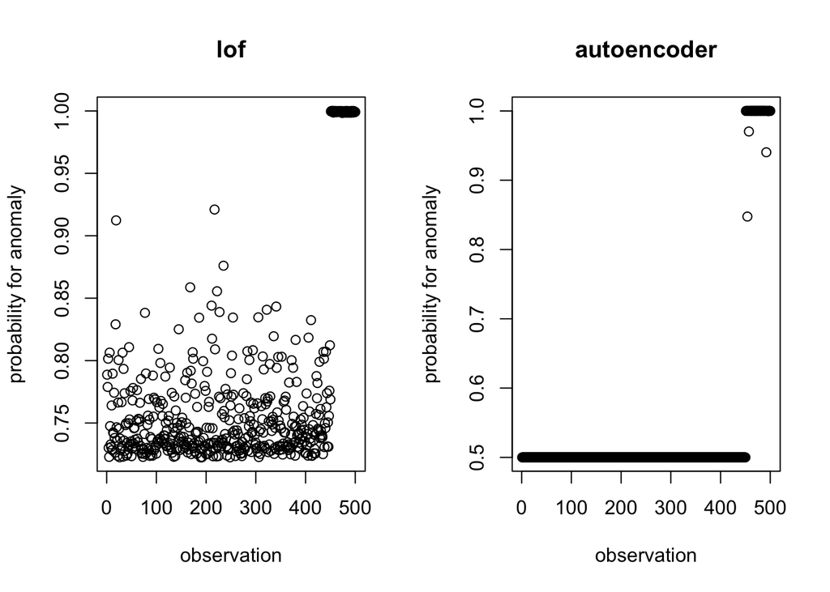

```r
par(mfrow = c(1,2))
n = length(pred.lof$data$prob.Anomaly)
plot(1:n, pred.lof$data$prob.Anomaly, main = "lof", ylab = "probability for anomaly", xlab = "observation")
plot(1:n, pred.ae$data$prob.Anomaly, main = "autoencoder", ylab = "probability for anomaly", xlab = "observation")
```

## Create a task

Usually, anomalous data sets don’t have labels and therefore are an unsupervised learning problem, however, in [%mlr] one-class classification learner inherits from the supervised class. The main purpose is to be able to use all binary classification measure in case labels are given for the test sets. Anomaly benchmark data, in general, provides labels for users to evaluate their methods. The one-class classification case in [%mlr] is built for that case.

Before creating a OneClassTask problem you have to bring your data in the right format if it doesn’t have a column containing the class labels. In case labels are missing create a synthetic column with only one class (e.g. name the column ‘Target’ and fill it with the label ‘Normal’). If you have the right format you can create a OneClassTask, but unlike the other learning problem, you *always* need to specify which column is the label/target column and which label stands for the *anomaly* class (positive) and which for the *normal* class (negative). As already mentioned above one-class classification only trains on one-class, the normal class, so you need to tell [%mlr] what the other class is. In the following example, we used the synthetic created data from the already existing oneclass2d.task in [%mlr] for anomaly data, which has a label column.

```r
data = getTaskData(oneclass2d.task)
train.set = 1:550
test.set = 551:1050

task = makeOneClassTask(id = "oneclass", data = data, target = "Target", positive = "Anomaly", negative = "Normal")
task
```

```
## Supervised task: oneclass
## Type: oneclass
## Target: Target
## Observations: 1050
## Features:
##    numerics     factors     ordered functionals
##           2           0           0           0
## Missings: FALSE
## Has weights: FALSE
## Has blocking: FALSE
## Classes: 2
## Anomaly  Normal
##      50    1000
## Positive/Anomaly class: Anomaly
## Negative/Normal class: Normal
```

## Constructing a learner

One-class classification in [%mlr] is currently containing three methods: * Support vector machines

- Autoencoder (Artificial neural network)
- Local Outlier Factor (LOF)

All current learners in [%mlr] for one-class classification can have a response or probability output. The characteristic of the response output will be specified when the learner is introduced below. For the probabilistic output in [%mlr], we are using anomaly scores, which are the usual output of anomaly detection methods. Anomaly scores indicate to which degree an observation is anomalous (relative to the other observations). Depending on the methods the scores are constructed differently and therefore can have different ranges and meaning, while they lead to the same interpretation. An advantage of [%mlr] is the consistent structure of the package and to keep the consistency the scores output, returned by each learner are transformed to the range of [0,1]. Although this output is called *probability* within the [%mlr] package, it should not exactly be interpreted as a probability but more as a normalized score. For more information about the transformation see the help page of [&convertingScoresToProbability].

### Support vector machines

Support vector machines are well known for analyzing data for classification and regression analysis. SVMs can also apply to detect anomalies by “creating a spherical decision boundary around a set of [normal] data points”[Karatzoglou et al., 2004, p.9]. In **R** the package s [%e1071] and [%kernlab] are providing the algorithm to do so.

```r
lrn.svm = makeLearner("oneclass.svm", predict.type = "prob")
lrn.ksvm = makeLearner("oneclass.ksvm")
lrn.ksvm
```

```
## Learner oneclass.ksvm from package kernlab
## Type: oneclass
## Name: one-class kernlab-based SVM; Short name: ksvm
## Class: oneclass.ksvm
## Properties: oneclass,numerics,factors,prob
## Predict-Type: response
## Hyperparameters:
```

The anomaly scores, also called decision values, from both packages, are indicating the distance to the decision boundaries. Both packages are also returned a response output, which is received by thresholding of the decision values. The threshold is per default set to 0, or in other words scores are positive for normal points and negative for anomalies in [%e1071] and [%kernlab]. The lower the score the more likely the related observation is anomalous. When using the method in [%mlr], the output is automatically normalized to [0,1] as previously explained. And according to [&convertingScoresToProbability], after transformation $1-f(score)$ is used for the probability column.

### Autoencoder (Artificial neural network)

A special case of a neural network is an autoencoder. The main idea of an autoencoder is to set the output data identical to the input data in the neural network and to train the model to reconstruct the input, with the objective to minimize the reconstruction error [Dau et al.2014, p.314]. But this approach requires to only use the data with the normal class in the training, to make sure the networks learn the pattern of the normal class and therefore classifies previously unseen observations which match the normal pattern as normal otherwise as anomalies [Dau et al. 2014, p.311]. In **R** the package [%h2o] provides an algorithm for an autoencoder. In [%mlr] you can currently specify up to three layers, by first setting the number of layers in the *layer* parameter and for each layer the number of nodes with *nodes1*, *nodes2*, *nodes3*.

```r
lrn.h2o = makeLearner("oneclass.h2o.autoencoder", par.vals = list(reproducible = T, seed = 1234),
  predict.type = "prob", predict.threshold = 0.95, reproducible = TRUE,
  layers = 2, nodes1 = 20, nodes2 = 10,
  # following settings were made to stabilise the model
  activation = "Tanh", l2 = 1e-5, sparse = TRUE, max_w2 = 10)
lrn.h2o
```

```
## Learner oneclass.h2o.autoencoder from package h2o
## Type: oneclass
## Name: h2o.autoencoder; Short name: h2o.ae
## Class: oneclass.h2o.autoencoder
## Properties: oneclass,numerics,factors,weights,prob
## Predict-Type: prob
## Hyperparameters: reproducible=TRUE,seed=1.23e+03,layers=2,nodes1=20,nodes2=10,activation=Tanh,l2=1e-05,sparse=TRUE,max_w2=10
```

As explained above, the autoencoder is producing a reconstruction error (mse between output and input layer in [&h2o]), which is the anomaly score. A high score or high mse means that the reconstruction error wasn’t accurate, which tend to imply that the observation was rather anomalous. According to [&convertingScoresToProbability], after transformation $f(score)$ is used for the probability column. If you set the *predict.type* as *response*, [&mlr] applies a soft threshold of the 95%-quantile to the scores. Scores above the 95%-quantile are considered to be an anomaly.

### Local Outlier Factor (LOF)

```r
# The number of neighbours (k) that will be used in the calculation of the local
# outlier factors must be set by the user
lrn.lof = makeLearner("oneclass.lofactor", k = 50, predict.type = "prob")
lrn.lof
```

```
## Learner oneclass.lofactor from package DMwR
## Type: oneclass
## Name: one-class LoF; Short name: lofactor
## Class: oneclass.lofactor
## Properties: oneclass,numerics,factors,prob
## Predict-Type: prob
## Hyperparameters: k=50
```

The local outlier factor is returning a score indicating the dense of the local density (locality is defined by *k*). A low local density indicates that the observation lies in a region that is sparser than that of its neighbors, and thus it is more likely to be anomalous. According to [&convertingScoresToProbability], after transformation $f(score)$ is used for the probability column. If you set the *predict.type* as *response*, [&mlr] applies a soft threshold of the 95%-quantile to the scores. Scores above the 95%-quantile are considered to be an anomaly.

## Train

You can [&train] a model as usual with a oneclass learner and a oneclass task as input. You can pass a `subset` or a `newdata set`.

```r
mod.ksvm = train(lrn.ksvm, task, subset = train.set)
mod.svm = train(lrn.svm, task, subset = train.set)
mod.lof = train(lrn.lof, task, subset = train.set)
mod.ae = train(lrn.ae, task, subset = train.set)
```

## Predict

Prediction can be done as usual in [%mlr] with predict and by passing a trained model and either the task to the `task` argument or some new data to the `newdata` argument. As always you can specify a `subset` of the data which should be predicted. In section Constructing a Learner), the specialities of the probability and response output are explained.

```r
pred.ksvm = predict(mod.ksvm, task, subset = test.set)
pred.svm = predict(mod.svm, task, subset = test.set)
pred.ae = predict(mod.ae, task, subset = test.set)
```

The training of LOF in [&mlr] is different than the other learners, as LOF is an unsupervised learning method. To apply LOF from the [&DMwR] package, no test and train data are needed. To keep the structure of mlr, to enable tuning and to allow binary supervised evaluation methods if labels are provided we adapt the [&lofactor] function to [&mlr]. That is that the (&train) and the (&test) function are independent. Which means that the (&train) function returns a prediction of the train data and the (&test) functions return a prediction of the test data based on the test data themselves, without needing the trained model. [&mlr] returns a message for the user.

```r
pred.lof = predict(mod.lof, task, subset = test.set)
```

```
## lof method is unsupervised, therefore predict()-fct trains and predicts on the same data
```

## Performance

If the true labels are given you can use binary classification evaluation methods.

```r
performance(pred.ksvm, measures = list(bac, f1, mmce))
```

```
##       bac        f1      mmce
## 0.8877778 0.4975124 0.2020000
```

Binary classification evaluation methods consider the two classes as equal. However, in anomaly detection, the anomaly class is more interesting for the user. [&mlr] also implemented additional evaluation methods for evaluating anomaly detection methods in case true labels are provided. One method is *weighted accuracy (wac)* a modification of the *balanced accuracy (bac)*, for which the user needs to set the weight (in [0,1]) of the importance of anomaly class relative to the normal class. If the weight is set to 0.5 the *wac* equals the *bac*. *Bac* measure returns values between 0 and 1, whereas 1 indicates perfect prediction.

```r
wac = makeWACMeasure(id = "wac", w = 0.6) #weight of the anomaly class is set to 0.6
performance(pred.svm, measures = list(wac))
```

```
##       wac
## 0.7848889
```

The other methods are *R-Precision measure/top p-accuracy*, *precision at p* and *average precision* (see [Campos et al., 2016]), which are specially aimed to evaluate anomaly detection models. For using this measures, you need to create them first with [&makePrecisionMeasure]. More information is in [Campos et al., 2016] and the help page [&makePrecisionMeasure]. All three measures return values between 0 and 1, whereas 1 indicates perfect prediction.

```r
## additional measurement for evaluating anomaly detection methods using labels are also implemented in R
## for using those measurement, create them first
rprecision = makePrecisionMeasure(id = "RPrecision", type = "rprecision", adjusted = FALSE)
precisionat5 = makePrecisionMeasure(id = "Precisionat5", p = 5, type = "precisionatp", adjusted = FALSE)
avgprecision = makePrecisionMeasure(id = "AvgPrecision", type = "avgprecision", adjusted = FALSE)

performance(pred.lof, measures = list(rprecision, precisionat5, avgprecision))
```

```
##   RPrecision Precisionat5 AvgPrecision
##   0.14000000   0.20000000   0.09711221
```

A key challenge in anomaly detection is, that usually no labels are available and in that case all introduced measures above are not applicable. For that case [&mlr] provides the *Area under the Mass-Volume Curve (AMV)* measurement according to [Thomas et al., 2016] for dimension smaller than eight. This measure needs be created with [&makeAMVMeasure]. For datasets with greater dimension than eight [&mlr] provides the *Area under the Mass-Volume Curve for high dimensional data (AMVhd)* according to [Goix, 2016], analogous use [&makeAMVhdMeasure] to create the measurement. More information is provided in the named paper and the help page [&makeAMVMeasure] and [&makeAMVhdMeasure].

```r
## additional measurement for evaluating anomaly detection methods without using labels are also implemented in R
## for using those measurement, create them first (here for demonstration purpose set low n.alpha and n.sim)
## for dimension <= 8 use makeAMVMeasure
amv = makeAMVMeasure(id = "AMV", alphas = c(0.8, 0.99), n.alpha = 10, n.sim = 100)
## for dimension > 8 use makeAMVhdMeasure
amvhd = makeAMVhdMeasure(id = "AMV", alphas = c(0.8, 0.99), n.alpha = 10, n.sim = 100)
performance(model = mod.ae, pred = pred.ae, task = task, measures = list(amv))
```

```
##     AMV
## 613.373
```

## Tuning/benchmark experiment

A challenge in anomaly detection is to set the parameters, which is not an easy task. If you have data with labels, you can tune a model using a supervised binary measurement and use this model on unlabelled data. If you don’t have labeled data, you can tune a model using an unsupervised binary measurement like *amv* or *amvhd*. A tuning example for all implemented anomaly detection is provided below using the oneclass2d.task.

### Defining the resampling strategy for one-class classification

For one-class classification tuning you can use the standard [resampling strategy] (resample.md#defining-the-resampling-strategy), especially if you don’t have labels. But if you have labels it is recommended to use a resampling strategy designed for the one-class classification task, which are: `OCHoldhout`, `OCCV`, `OCSubsample`, `OCBootsrap`, `OCRepCV`, to assure to only have normal data during the training. `OCHoldhout`,`OCSubsample`, `OCBootsrap` are basically sampling only normal observations for the training data set and the rest are using for testing. `OCCV` and `OCRepCV` split the anomalous observations in k-folds, when a fold became the training set it drops the anomalies for training. These strategies can be called as usual in [&mlr] with the [&makeResampleDesc] function.

```r
# Set outer resampling strategy
outer = makeResampleDesc("OCBootstrap", iters = 3)
rin = makeResampleInstance(outer, oneclass2d.task)

# Set inner resampling strategy
inner = makeResampleDesc("CV", iters = 3)
```

### Specifying the optimization algorithm

For tuning an anomaly detection learner, you need to always create a learner with a `prob` output. Because, if you want to tune an anomaly learner using *1. a supervised measurement (e.g. `f1` or `average precision`), you should tune the threshold, as those measures based on the number of correct predicted anomalies or true predicted normal points.

*2. an unsupervised measurement like `avm` or `amvhd`, no threshold is needed, but the algorithm of those measures are based on an anomaly scores, which is the probability output in [&mlr]

```r
# Set search strategy (maxit is low to run this example)
ctrl = makeTuneControlRandom(maxit = 5L, tune.threshold = TRUE)
```

### Performing the benchmark experiment

```r
### parameter for svm
ps.svm = makeParamSet(
  makeNumericParam("nu",  lower = 0.01, upper = 0.99),
  makeDiscreteParam("kernel", values = c("linear", "polynomial", "radial", "sigmoid")),
  makeIntegerParam("degree", lower = 1L, upper = 4L, requires = quote(kernel == "polynomial")),
  makeNumericParam("coef0", lower = 0, upper = 3, requires = quote(kernel == "polynomial" || kernel == "sigmoid"))
)

### parameter for lofactor
ps.lofactor = makeParamSet(
  makeIntegerParam("k", lower = 20, upper = 200))
```

For the *oneclass.ksvm* learner there is an exception for setting the search space for the `sigma` parameter, see Tuning.

```r
### parameter for ksvm
ps.ksvm = makeParamSet(
  makeNumericParam("nu",  lower = 0.01, upper = 0.99),
  makeDiscreteParam("kernel", values = c("vanilladot", "polydot", "rbfdot", "tanhdot")),
  makeIntegerParam("degree", lower = 1L, upper = 4L, requires = quote(kernel %in% c("polydot", "anovadot", "besseldot"))),
  # for sigma
  makeNumericParam("sigma", lower = -10, upper = 10, trafo = function(x) 10^x, require = quote(kernel %in% c("rbfdot", "anovadot", "besseldot", "laplacedot"))),
  makeNumericParam("scale", lower = 0, upper = 1, requires = quote(kernel %in% c("polydot", "tanhdot"))),
  makeNumericParam("offset", lower = 0, upper = 3, requires = quote(kernel %in% c("polydot", "tanhdot"))),
  makeIntegerParam(id = "order", lower = 1, upper = 3, requires = quote(kernel == "besseldot"))
)
```

There is also an exception fot the *oneclass.h2o.autoencoder*. [&mlr] enable to tune for number of layers and nodes up to three layers.

```r
### parameter for autoencoder
ps.h2o = makeParamSet(
  makeIntegerParam(id = "layers", lower = 1L, upper = 3L, default = 1L),
  makeIntegerParam(id = "nodes1", lower = 150L, upper = 250, default = 200L),
  makeIntegerParam(id = "nodes2", lower = 150L, upper = 250, default = 200L,
    requires = quote(layers > 1)),
  makeIntegerParam(id = "nodes3", lower = 150L, upper = 250, default = 200L,
    requires = quote(layers > 2))
)
```

```r
# make lofactor learner and tunewrapper
lrn.svm = makeLearner("oneclass.svm", predict.type = "prob")
lrn.svm = makeTuneWrapper(lrn.svm, resampling = inner, par.set = ps.svm, measures = list(f1),
  control = ctrl, show.info = TRUE)

# make lofactor learner and tunewrapper
lrn.ksvm = makeLearner("oneclass.ksvm", predict.type = "prob")
lrn.ksvm = makeTuneWrapper(lrn.ksvm, resampling = inner, par.set = ps.ksvm, measures = list(f1),
  control = ctrl, show.info = TRUE)

# make lofactor learner and tunewrapper
#lrn.lofactor = makeLearner("oneclass.lofactor", predict.type = "prob")
#lrn.lofactor = makeTuneWrapper(lrn.lofactor, resampling = inner, par.set = ps.lofactor, measures = list(f1),
#  control = ctrl, show.info = TRUE)

# make autoencoder learner and tunewrapper
lrn.h2o = makeLearner("oneclass.h2o.autoencoder", predict.type = "prob", activation = "Tanh",
  reproducible = TRUE, mini_batch_size = 4, loss = "Quadratic", adaptive_rate = TRUE, l2=1e-5,
  sparse = TRUE, max_w2=10, train_samples_per_iteration = -1)
lrn.h2o = makeTuneWrapper(lrn.h2o, resampling = inner, par.set = ps.h2o, measures = list(f1),
  control = ctrl, show.info = TRUE)
lrns = list(lrn.svm)
#lrns = list(lrn.svm, lrn.ksvm, lrn.ae, lrn.lof)
res = benchmark(lrns, oneclass2d.task, rin, measures = list(f1))
```

```
## Task: one-class-2d-example, Learner: oneclass.svm.tuned
```

```
## Resampling: OOB bootstrapping for oneclass-classification
```

```
## Measures:             f1
```

```
## [Tune] Started tuning learner oneclass.svm for parameter set:
```

```
##            Type len Def                           Constr Req Tunable Trafo
## nu      numeric   -   -                     0.01 to 0.99   -    TRUE     -
## kernel discrete   -   - linear,polynomial,radial,sigmoid   -    TRUE     -
## degree  integer   -   -                           1 to 4   Y    TRUE     -
## coef0   numeric   -   -                           0 to 3   Y    TRUE     -
```

```
## With control class: TuneControlRandom
```

```
## Imputation value: -0
```

```
## [Tune-x] 1: nu=0.672; kernel=radial
```

```
## [Tune-y] 1: f1.test.mean=0.0000000; time: 0.0 min
```

```
## [Tune-x] 2: nu=0.146; kernel=polynomial; degree=1; coef0=0.499
```

```
## [Tune-y] 2: f1.test.mean=0.0000000; time: 0.0 min
```

```
## [Tune-x] 3: nu=0.25; kernel=radial
```

```
## [Tune-y] 3: f1.test.mean=0.0000000; time: 0.0 min
```

```
## [Tune-x] 4: nu=0.352; kernel=sigmoid; coef0=2.18
```

```
## [Tune-y] 4: f1.test.mean=0.0000000; time: 0.0 min
```

```
## [Tune-x] 5: nu=0.871; kernel=polynomial; degree=4; coef0=2.29
```

```
## [Tune-y] 5: f1.test.mean=0.0000000; time: 0.0 min
```

```
## [Tune] Result: nu=0.352; kernel=sigmoid; coef0=2.18 : f1.test.mean=0.0000000
```

```
## [Resample] iter 1:    0.4629630
```

```
## [Tune] Started tuning learner oneclass.svm for parameter set:
```

```
##            Type len Def                           Constr Req Tunable Trafo
## nu      numeric   -   -                     0.01 to 0.99   -    TRUE     -
## kernel discrete   -   - linear,polynomial,radial,sigmoid   -    TRUE     -
## degree  integer   -   -                           1 to 4   Y    TRUE     -
## coef0   numeric   -   -                           0 to 3   Y    TRUE     -
```

```
## With control class: TuneControlRandom
```

```
## Imputation value: -0
```

```
## [Tune-x] 1: nu=0.204; kernel=sigmoid; coef0=2.47
```

```
## [Tune-y] 1: f1.test.mean=0.0000000; time: 0.0 min
```

```
## [Tune-x] 2: nu=0.758; kernel=polynomial; degree=2; coef0=2.31
```

```
## [Tune-y] 2: f1.test.mean=0.0000000; time: 0.0 min
```

```
## [Tune-x] 3: nu=0.515; kernel=radial
```

```
## [Tune-y] 3: f1.test.mean=0.0000000; time: 0.0 min
```

```
## [Tune-x] 4: nu=0.156; kernel=polynomial; degree=2; coef0=1.36
```

```
## [Tune-y] 4: f1.test.mean=0.0000000; time: 0.0 min
```

```
## [Tune-x] 5: nu=0.617; kernel=radial
```

```
## [Tune-y] 5: f1.test.mean=0.0000000; time: 0.0 min
```

```
## [Tune] Result: nu=0.204; kernel=sigmoid; coef0=2.47 : f1.test.mean=0.0000000
```

```
## [Resample] iter 2:    0.6756757
```

```
## [Tune] Started tuning learner oneclass.svm for parameter set:
```

```
##            Type len Def                           Constr Req Tunable Trafo
## nu      numeric   -   -                     0.01 to 0.99   -    TRUE     -
## kernel discrete   -   - linear,polynomial,radial,sigmoid   -    TRUE     -
## degree  integer   -   -                           1 to 4   Y    TRUE     -
## coef0   numeric   -   -                           0 to 3   Y    TRUE     -
```

```
## With control class: TuneControlRandom
```

```
## Imputation value: -0
```

```
## [Tune-x] 1: nu=0.233; kernel=polynomial; degree=1; coef0=1.45
```

```
## [Tune-y] 1: f1.test.mean=0.0000000; time: 0.0 min
```

```
## [Tune-x] 2: nu=0.89; kernel=radial
```

```
## [Tune-y] 2: f1.test.mean=0.0000000; time: 0.0 min
```

```
## [Tune-x] 3: nu=0.64; kernel=polynomial; degree=4; coef0=2.08
```

```
## [Tune-y] 3: f1.test.mean=0.0000000; time: 0.0 min
```

```
## [Tune-x] 4: nu=0.173; kernel=polynomial; degree=3; coef0=1.07
```

```
## [Tune-y] 4: f1.test.mean=0.0000000; time: 0.0 min
```

```
## [Tune-x] 5: nu=0.787; kernel=sigmoid; coef0=1.13
```

```
## [Tune-y] 5: f1.test.mean=0.0000000; time: 0.0 min
```

```
## [Tune] Result: nu=0.787; kernel=sigmoid; coef0=1.13 : f1.test.mean=0.0000000
```

```
## [Resample] iter 3:    0.2816901
```

```
## Aggregated Result: f1.test.mean=0.4734429
```

```r
getBMRPerformances(res, as.df = TRUE)
```

```
##                task.id         learner.id iter        f1
## 1 one-class-2d-example oneclass.svm.tuned    1 0.4629630
## 2 one-class-2d-example oneclass.svm.tuned    2 0.6756757
## 3 one-class-2d-example oneclass.svm.tuned    3 0.2816901
```

## References

Mennatallah Amer, Markus Goldstein, and Slim Abdennadher. Enhancing one-class support vector machines for unsupervised anomaly detection. In Proceedings of the ACM SIGKDD Workshop on Outlier Detection and Description, pages 8–15. ACM, 2013.

Varun Chandola, Arindam Banerjee, and Vipin Kumar. Anomaly detection: A survey. ACM Comput. Surv., 41(3):15:1–15:58, July 2009. ISSN 0360-0300. doi: 10. 1145/1541880.1541882. URL http://doi.acm.org/10.1145/1541880.1541882.

Anh Hoang Dau, Victor Ciesielski, and Andy Song. Anomaly detection using replicator neural networks trained on examples of one class. In SEAL, pages 311–322, 2014.

Michael R Smith and Tony Martinez. Improving classification accuracy by identifying and removing instances that should be misclassified. In Neural Networks (IJCNN), The 2011 International Joint Conference on, pages 2690–2697. IEEE, 2011.

Victoria Hodge and Jim Austin. A survey of outlier detection methodologies. Artificial intelligence review, 22(2):85–126, 2004.

Vipin Kumar. Parallel and distributed computing for cybersecurity. IEEE Distributed Systems Online, 6(10), 2005.

Alexandros Karatzoglou, Alex Smola, Kurt Hornik, and Achim Zeileis. kernlab – an S4 package for kernel methods in R. Journal of Statistical Software, 11(9):1–20, 2004. URL http://www.jstatsoft.org/v11/i09/.

Guilherme O Campos, Arthur Zimek, Jörg Sander, Ricardo JGB Campello, Barbora Micenková, Erich Schubert, Ira Assent, and Michael E Houle. On the evaluation of unsupervised outlier detection: measures, datasets, and an empirical study. Data Mining and Knowledge Discovery, 30(4):891–927, 2016.

Albert Thomas, Stephan Clemencon, Feuilard Vincent, and Alexandre Gramfort. Learning hyperparameters for unsupervised anomaly detection. Anomaly Detection Workshop, ICML 2016, 2016.

Nicolas Goix. How to evaluate the quality of unsupervised anomaly detection algorithms? arXiv preprint arXiv:1607.01152, 2016.